# First Visual Stationarity Checks

Thesis SVAR project

2026-06-15

This notebook gives a first visual check of the variables that may enter the SVAR.

The goal is not to decide the final model yet. In this first step, we only compare:

- plots in levels;
- ACF and PACF plots, which help us see persistence.

## 1. Load The Data

```r
data_dir <- "data"

parse_month <- function(x) {
  as.Date(paste0("01-", x), format = "%d-%m-%Y")
}

parse_euro_number <- function(x) {
  x <- gsub("\\.", "", x)
  x <- gsub(",", ".", x)
  as.numeric(x)
}

read_semicolon_series <- function(file, value_name, new_name) {
  raw <- read.csv(
    file.path(data_dir, file),
    sep = ";",
    stringsAsFactors = FALSE,
    check.names = FALSE
  )

  data.frame(
    Date = parse_month(raw$Date),
    value = parse_euro_number(raw[[value_name]]),
    variable = new_name
  )
}

read_comma_series <- function(file, value_name, new_name) {
  raw <- read.csv(
    file.path(data_dir, file),
    sep = ",",
    stringsAsFactors = FALSE,
    check.names = FALSE
  )

  data.frame(
    Date = parse_month(raw$Date),
    value = as.numeric(raw[[value_name]]),
    variable = new_name
  )
}

pun <- read_semicolon_series("pun.csv", "PUN (€/MWh)", "PUN")
gas <- read_semicolon_series("natural_gas.csv", "Natural gas Europe (€/MWh)", "Natural gas")
res <- read_comma_series("italy_res_capacity_monthly.csv", "RES Installed Capacity (MW)", "RES capacity")
hdd <- read_comma_series("hdd.csv", "heating_degree_days", "Heating degree days")
cdd <- read_comma_series("cdd.csv", "cooling_degree_days", "Cooling degree days")
cons <- read_semicolon_series("energy_consumption.csv", "Volumi MWh", "Electricity consumption")

all_data <- rbind(pun, gas, res, hdd, cdd, cons)

summary(all_data)
```

```
##       Date                value            variable
##  Min.   :1960-01-01   Min.   :       0   Length:2207
##  1st Qu.:2001-12-16   1st Qu.:       9   Class :character
##  Median :2010-11-01   Median :      38   Mode  :character
##  Mean   :2006-09-02   Mean   : 2944201
##  3rd Qu.:2018-07-01   3rd Qu.:     295
##  Max.   :2026-06-01   Max.   :29894176
```

## 2. Keep The Common Monthly Sample

For a VAR or SVAR, all variables need to be observed over the same dates. The common sample is from January 2005 to December 2025.

I also exclude 2026 here because the June 2026 electricity consumption observation looks incomplete.

```r
start_date <- as.Date("2005-01-01")
end_date <- as.Date("2025-12-01")

plot_data <- all_data[
  all_data$Date >= start_date &
    all_data$Date <= end_date,
]

plot_data$year <- as.numeric(format(plot_data$Date, "%Y"))
plot_data$month <- as.numeric(format(plot_data$Date, "%m"))
plot_data$month_name <- factor(
  months(plot_data$Date),
  levels = months(as.Date(paste0("2025-", sprintf("%02d", 1:12), "-01")))
)

table(plot_data$variable)
```

```
##
##     Cooling degree days Electricity consumption     Heating degree days
##                     252                     252                     252
##             Natural gas                     PUN            RES capacity
##                     252                     252                     252
```

## 3. Variables In Levels

This section looks at the original variables.

For each variable, we plot:

- the time series;
- the ACF;
- the PACF.

If the time series has a clear trend, or if the ACF decays very slowly, the variable may not be stationary in levels.

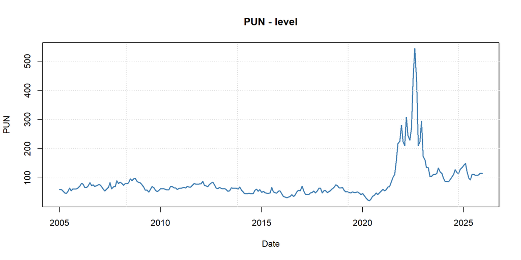

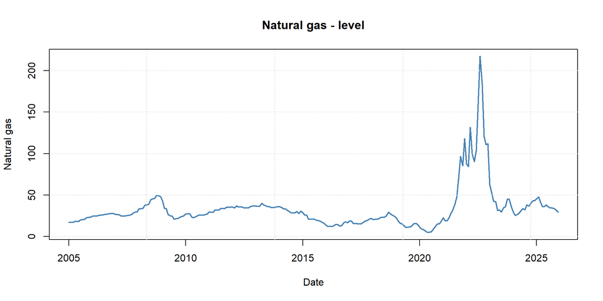

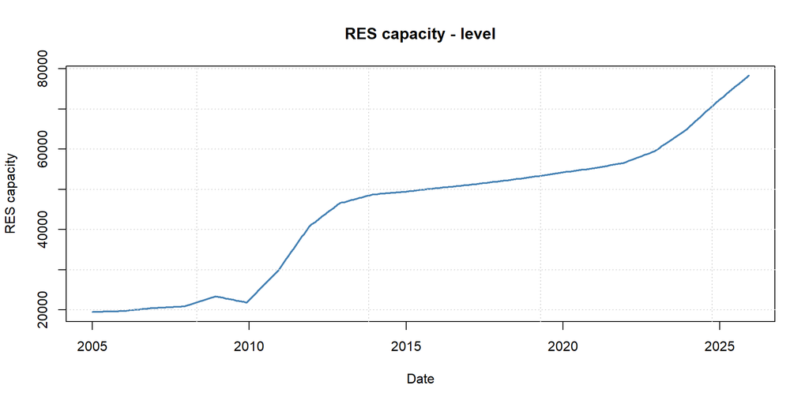

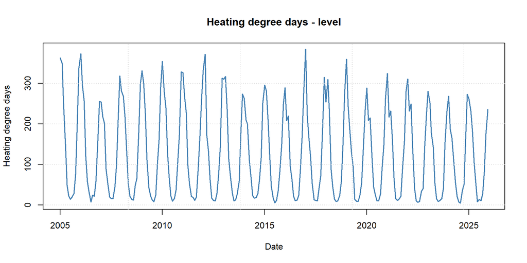

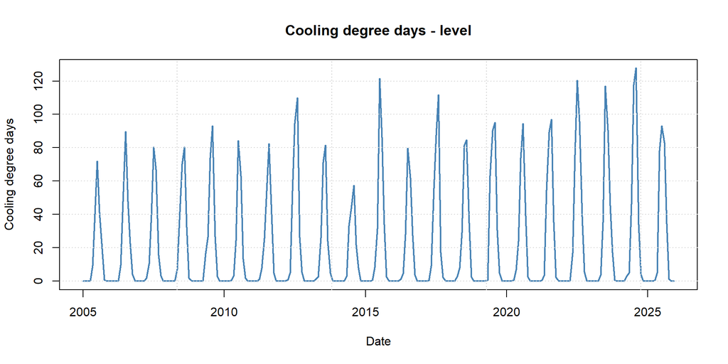

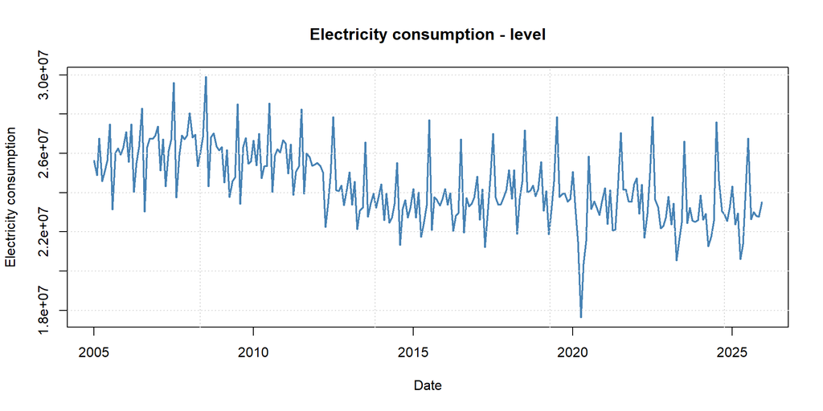

```r
variables <- unique(plot_data$variable)

for (v in variables) {
  x <- plot_data[plot_data$variable == v, ]

  plot_level <- function() {
    plot(
      x$Date,
      x$value,
      type = "l",
      main = paste(v, "- level"),
      xlab = "Date",
      ylab = v,
      col = "steelblue",
      lwd = 2
    )
    grid()
  }

  plot_level()

  save_plot(
    make_plot_name(v, "level_time_series.png"),
    plot_level()
  )
}
```

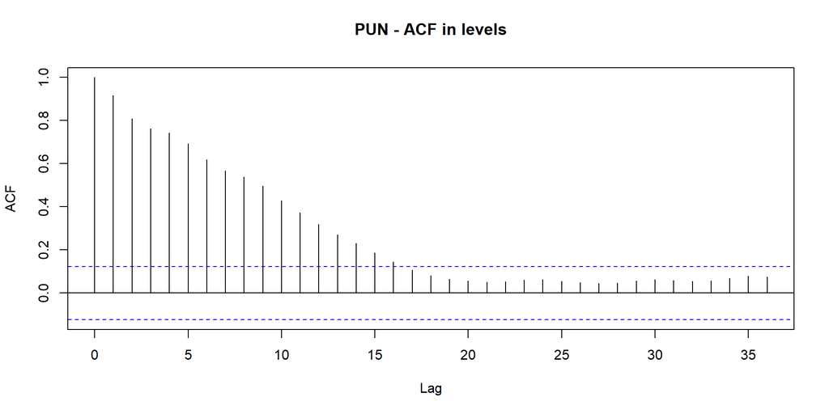

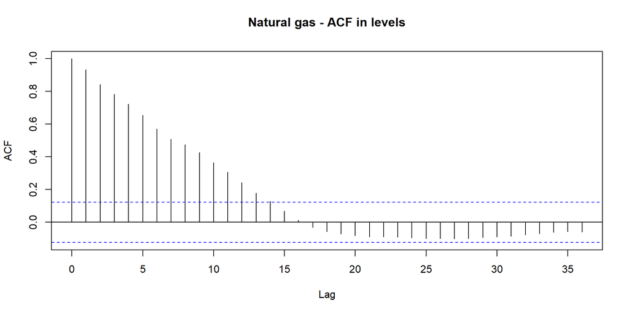

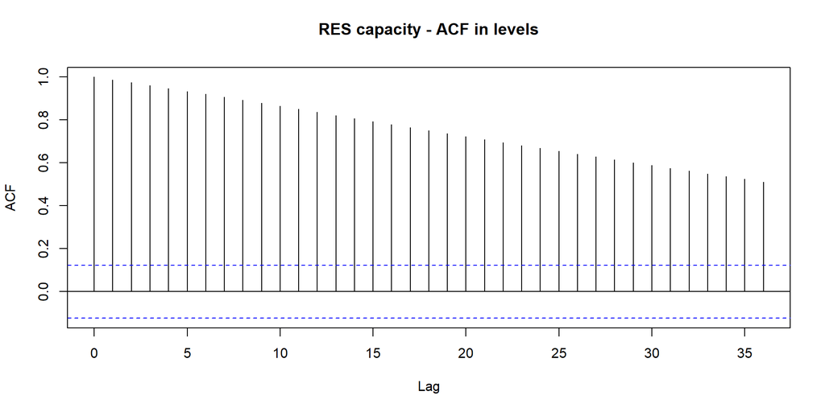

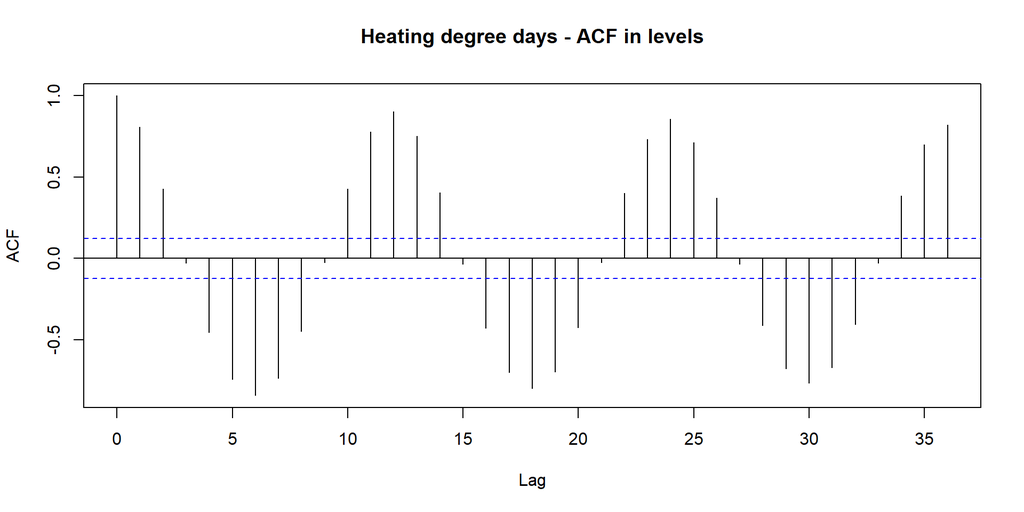

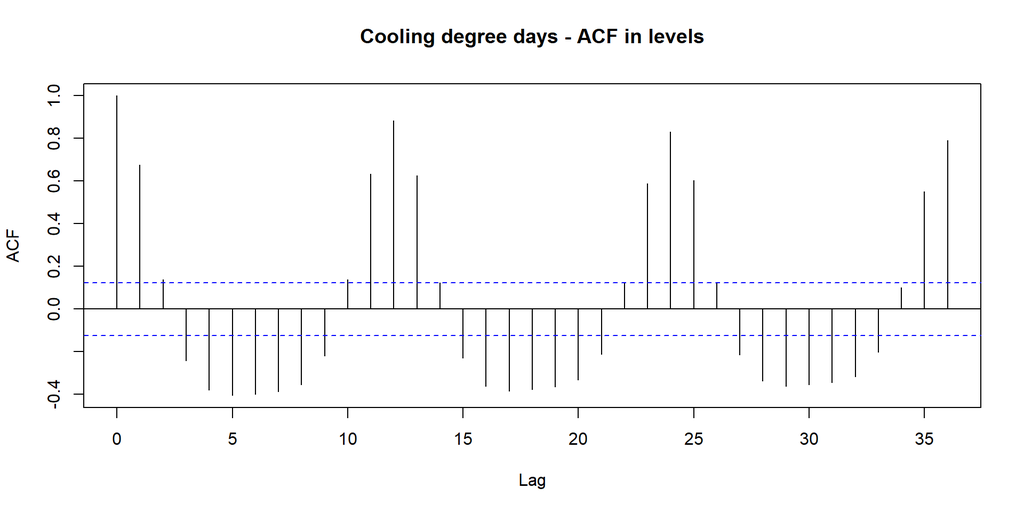

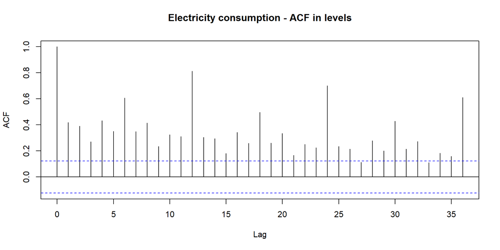

```r
for (v in variables) {
  x <- plot_data[plot_data$variable == v, ]

  plot_acf <- function() {
    acf(
      x$value,
      lag.max = 36,
      main = paste(v, "- ACF in levels")
    )
  }

  plot_acf()

  save_plot(
    make_plot_name(v, "acf_levels.png"),
    plot_acf()
  )
}
```

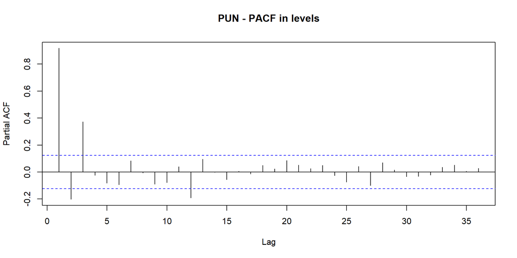

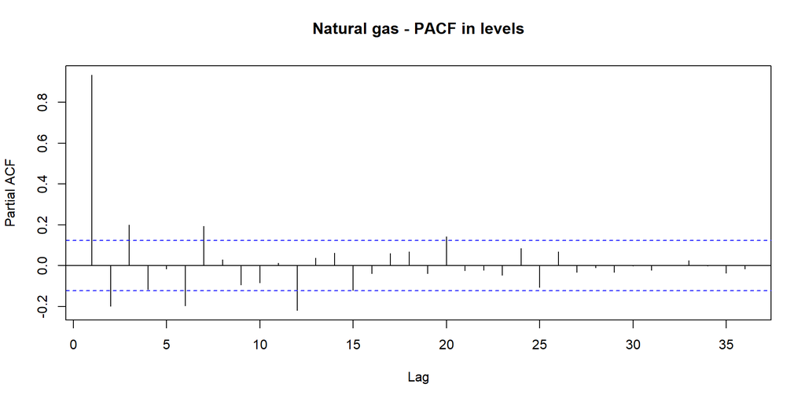

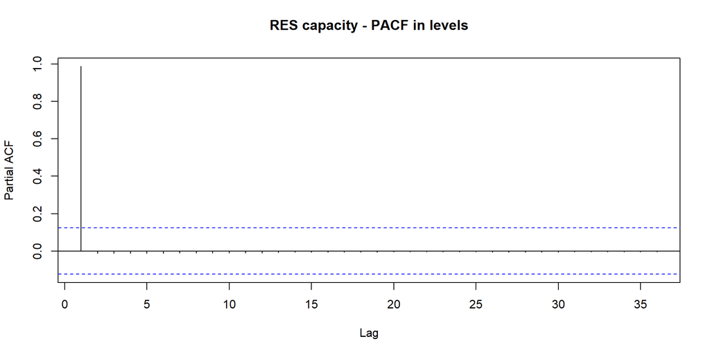

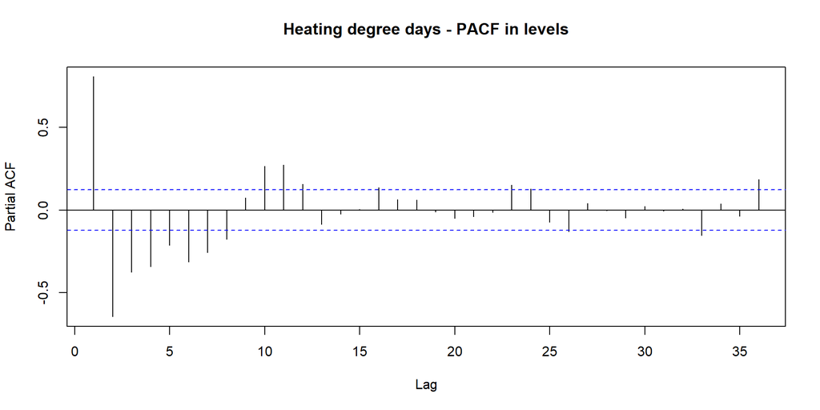

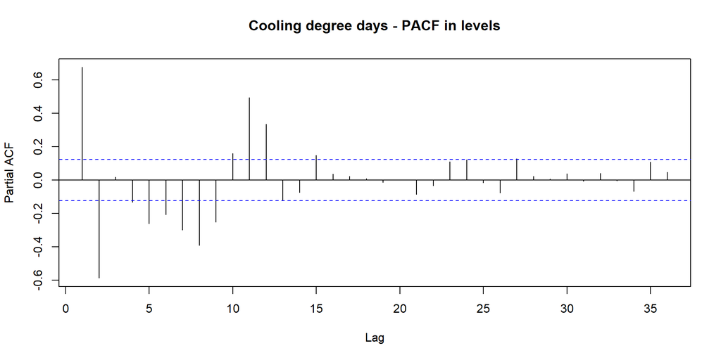

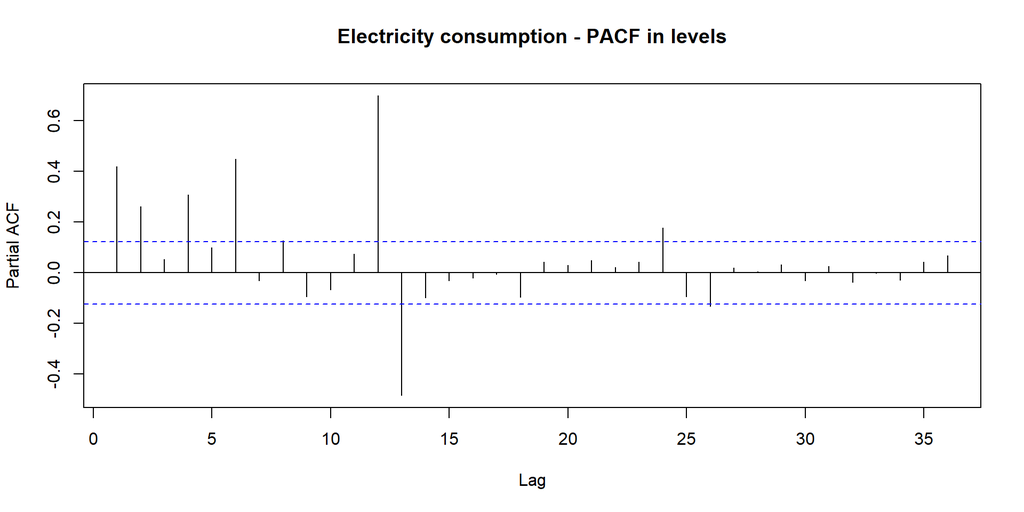

```r
for (v in variables) {
  x <- plot_data[plot_data$variable == v, ]

  plot_pacf <- function() {
    pacf(
      x$value,
      lag.max = 36,
      main = paste(v, "- PACF in levels")
    )
  }

  plot_pacf()

  save_plot(
    make_plot_name(v, "pacf_levels.png"),
    plot_pacf()
  )
}
```

## 4. Preliminary Transformations

This chunk prepares a first dataset for the SVAR analysis.

I log-transform PUN, natural gas, and electricity consumption. I also add monthly dummies, using January as the reference month.

```r
svar_long <- plot_data

log_variables <- c("PUN", "Natural gas", "Electricity consumption")

if (any(svar_long$value[svar_long$variable %in% log_variables] <= 0, na.rm = TRUE)) {
  stop("Log transformation requires strictly positive values.")
}

svar_long$value[svar_long$variable %in% log_variables] <- log(
  svar_long$value[svar_long$variable %in% log_variables]
)

svar_long$variable[svar_long$variable == "PUN"] <- "log_pun"
svar_long$variable[svar_long$variable == "Natural gas"] <- "log_natural_gas"
svar_long$variable[svar_long$variable == "Electricity consumption"] <- "log_electricity_consumption"
svar_long$variable[svar_long$variable == "RES capacity"] <- "res_capacity"
svar_long$variable[svar_long$variable == "Heating degree days"] <- "heating_degree_days"
svar_long$variable[svar_long$variable == "Cooling degree days"] <- "cooling_degree_days"

svar_data <- reshape(
  svar_long[, c("Date", "variable", "value")],
  idvar = "Date",
  timevar = "variable",
  direction = "wide"
)

names(svar_data) <- sub("^value\\.", "", names(svar_data))
svar_data <- svar_data[order(svar_data$Date), ]
row.names(svar_data) <- NULL

svar_data$month <- factor(
  format(svar_data$Date, "%m"),
  levels = sprintf("%02d", 1:12),
  labels = month.abb
)

month_dummies <- model.matrix(~ month, data = svar_data)[, -1]
colnames(month_dummies) <- paste0("month_", month.abb[-1])

svar_data <- cbind(svar_data, month_dummies)
svar_data$month <- NULL
```

## 5. ADF Stationarity Tests

The Augmented Dickey-Fuller test has this null hypothesis:

- the variable has a unit root, so it is not stationary.

If the p-value is below 0.05, we reject the null and treat the variable as stationary. This is still a preliminary check, not the final modelling decision. I use 12 lags because the data are monthly.

```r
if (!requireNamespace("tseries", quietly = TRUE)) {
  stop("Package 'tseries' is needed for the ADF test. Install it with install.packages('tseries').")
}

adf_variables <- names(svar_data)[
  names(svar_data) != "Date" &
    !grepl("^month_", names(svar_data))
]

adf_lag <- 12

adf_results <- do.call(
  rbind,
  lapply(adf_variables, function(v) {
    test <- tseries::adf.test(
      na.omit(svar_data[[v]]),
      k = adf_lag
    )

    data.frame(
      variable = v,
      lags = adf_lag,
      adf_statistic = as.numeric(test$statistic),
      p_value = test$p.value,
      conclusion = ifelse(
        test$p.value < 0.05,
        "Reject unit root: stationary",
        "Do not reject unit root: non-stationary"
      )
    )
  })
)

adf_results
```

```
##                      variable lags adf_statistic    p_value
## 1                     log_pun   12     -3.102762 0.11146901
## 2             log_natural_gas   12     -3.897386 0.01462871
## 3                res_capacity   12     -2.683425 0.28803572
## 4         heating_degree_days   12     -3.252198 0.07963098
## 5         cooling_degree_days   12     -3.496807 0.04357241
## 6 log_electricity_consumption   12     -2.326476 0.43833322
##                                conclusion
## 1 Do not reject unit root: non-stationary
## 2            Reject unit root: stationary
## 3 Do not reject unit root: non-stationary
## 4 Do not reject unit root: non-stationary
## 5            Reject unit root: stationary
## 6 Do not reject unit root: non-stationary
```

## 6. First Differences For Non-Stationary Logged Variables

The previous ADF test suggests that `log_pun` and `log_electricity_consumption` may still be non-stationary. As a next preliminary step, I take first differences of these two logged variables and run the ADF test again.

```r
diff_variables <- c("log_pun", "log_electricity_consumption")

diff_data <- data.frame(
  Date = svar_data$Date[-1]
)

for (v in diff_variables) {
  diff_data[[paste0("d_", v)]] <- diff(svar_data[[v]])
}

diff_adf_results <- do.call(
  rbind,
  lapply(names(diff_data)[names(diff_data) != "Date"], function(v) {
    test <- tseries::adf.test(
      na.omit(diff_data[[v]]),
      k = adf_lag
    )

    data.frame(
      variable = v,
      lags = adf_lag,
      adf_statistic = as.numeric(test$statistic),
      p_value = test$p.value,
      conclusion = ifelse(
        test$p.value < 0.05,
        "Reject unit root: stationary",
        "Do not reject unit root: non-stationary"
      )
    )
  })
)

diff_adf_results
```

```
##                        variable lags adf_statistic    p_value
## 1                     d_log_pun   12     -3.571877 0.03635797
## 2 d_log_electricity_consumption   12     -5.436096 0.01000000
##                     conclusion
## 1 Reject unit root: stationary
## 2 Reject unit root: stationary
```

## 7. Structural VAR With Cholesky Identification

This section estimates the thesis baseline SVAR.

The Cholesky ordering is:

1. `log_natural_gas`;
2. `d_log_energy_consumption`;
3. `d_log_pun`.

The weather variables, renewable capacity, and monthly dummies enter as exogenous variables. In the recursive forecast exercise, their realised values are used for the next month, so the exercise is conditional on these exogenous paths.

```r
if (!requireNamespace("vars", quietly = TRUE)) {
  stop("Package 'vars' is needed for the VAR and SVAR models. Install it with install.packages('vars').")
}

svar_variables <- c(
  "log_natural_gas",
  "d_log_energy_consumption",
  "d_log_pun"
)

monthly_dummy_variables <- grep("^month_", names(svar_data), value = TRUE)

exogenous_variables <- c(
  "heating_degree_days",
  "cooling_degree_days",
  "res_capacity",
  monthly_dummy_variables
)

svar_model_data <- svar_data[order(svar_data$Date), ]

# Data input placeholder for the final cleaned modelling dataset.
# If the data cleaning step is later moved to a separate script, replace
# this object with the imported final dataset with the same column names.
svar_model_data$d_log_energy_consumption <- c(
  NA,
  diff(svar_model_data$log_electricity_consumption)
)
svar_model_data$d_log_pun <- c(
  NA,
  diff(svar_model_data$log_pun)
)

required_svar_columns <- c(
  "Date",
  "log_natural_gas",
  "log_electricity_consumption",
  "log_pun",
  svar_variables,
  exogenous_variables
)

missing_svar_columns <- setdiff(required_svar_columns, names(svar_model_data))

if (length(missing_svar_columns) > 0) {
  stop(
    "The SVAR dataset is missing these columns: ",
    paste(missing_svar_columns, collapse = ", ")
  )
}

svar_input <- svar_model_data[
  complete.cases(svar_model_data[, required_svar_columns]),
  required_svar_columns
]

estimation_start <- as.Date("2005-01-01")
estimation_end <- as.Date("2019-12-01")
test_start <- as.Date("2020-01-01")
test_end <- as.Date("2025-12-01")

estimation_sample <- svar_input[
  svar_input$Date >= estimation_start & svar_input$Date <= estimation_end,
]

test_sample <- svar_input[
  svar_input$Date >= test_start & svar_input$Date <= test_end,
]

if (nrow(estimation_sample) == 0) {
  stop("The estimation sample is empty.")
}

if (nrow(test_sample) == 0) {
  stop("The test sample is empty.")
}

endog_estimation <- as.matrix(estimation_sample[, svar_variables])
exog_estimation <- as.matrix(estimation_sample[, exogenous_variables])

sample_sizes <- data.frame(
  sample = c("estimation", "test"),
  start = c(min(estimation_sample$Date), min(test_sample$Date)),
  end = c(max(estimation_sample$Date), max(test_sample$Date)),
  observations = c(nrow(estimation_sample), nrow(test_sample))
)

sample_sizes
```

```
##       sample      start        end observations
## 1 estimation 2005-02-01 2019-12-01          179
## 2       test 2020-01-01 2025-12-01           72
```

## 8. Lag Selection And Reduced-Form VAR

```r
lag_selection <- vars::VARselect(
  y = endog_estimation,
  lag.max = 12,
  type = "const",
  exogen = exog_estimation
)

lag_selection$criteria
```

```
##                    1             2             3             4             5
## AIC(n) -1.782922e+01 -1.788213e+01 -1.795785e+01 -1.815988e+01 -1.813175e+01
## HQ(n)  -1.742001e+01 -1.740472e+01 -1.741223e+01 -1.754606e+01 -1.744973e+01
## SC(n)  -1.682100e+01 -1.670588e+01 -1.661356e+01 -1.664756e+01 -1.645140e+01
## FPE(n)  1.811191e-08  1.720414e-08  1.598143e-08  1.309168e-08  1.350875e-08
##                    6             7             8             9            10
## AIC(n) -1.811065e+01 -1.810901e+01 -1.814161e+01 -1.816903e+01 -1.812952e+01
## HQ(n)  -1.736043e+01 -1.729059e+01 -1.725499e+01 -1.721420e+01 -1.710649e+01
## SC(n)  -1.626226e+01 -1.609259e+01 -1.595715e+01 -1.581653e+01 -1.560898e+01
## FPE(n)  1.385180e-08  1.394143e-08  1.357180e-08  1.329402e-08  1.393882e-08
##                   11            12
## AIC(n) -1.810584e+01 -1.812722e+01
## HQ(n)  -1.701461e+01 -1.696779e+01
## SC(n)  -1.541727e+01 -1.527062e+01
## FPE(n)  1.440268e-08  1.424523e-08
```

```r
selected_lag <- 12 # as.integer(lag_selection$selection[["AIC(n)"]])
selected_lag # 12 for annual seasonality
```

```
## [1] 12
```

```r
var_fit <- vars::VAR(
  y = endog_estimation,
  p = selected_lag,
  type = "const",
  exogen = exog_estimation
)

diagnostic_tests <- list(
  Portmanteau = vars::serial.test(
    var_fit,
    lags.pt = selected_lag + 12,
    type = "PT.asymptotic"
  )$serial,
  "Jarque-Bera" = vars::normality.test(
    var_fit,
    multivariate.only = TRUE
  )$jb.mul$JB,
  ARCH = vars::arch.test(
    var_fit,
    lags.multi = 5,
    multivariate.only = TRUE
  )$arch.mul
)

diagnostic_p_values <- sapply(
  diagnostic_tests,
  function(test) as.numeric(test$p.value)
)

var_diagnostics <- data.frame(
  test = names(diagnostic_tests),
  statistic = round(
    sapply(diagnostic_tests, function(test) as.numeric(test$statistic)),
    3
  ),
  df = sapply(
    diagnostic_tests,
    function(test) as.numeric(test$parameter)
  ),
  p_value = signif(diagnostic_p_values, 3),
  decision_5pct = ifelse(
    diagnostic_p_values < 0.05,
    "reject H0",
    "do not reject H0"
  )
)

var_diagnostics
```

```
##                    test statistic  df  p_value    decision_5pct
## Portmanteau Portmanteau   195.226 108 5.62e-07        reject H0
## Jarque-Bera Jarque-Bera    16.937   6 9.52e-03        reject H0
## ARCH               ARCH   164.419 180 7.91e-01 do not reject H0
```

```r
# summary(var_fit)
```

## 9. Cholesky A-Matrix And SVAR Estimation

For an A-model in `vars::SVAR()`, the `NA` entries are estimated and the numeric entries are restrictions.

With three variables, exact identification requires `K * (K - 1) / 2 = 3` restrictions. These are the three zero restrictions above the diagonal. The three lower off-diagonal entries are the contemporaneous Cholesky transmission parameters.

```r
k_endog <- length(svar_variables)

amat <- matrix(NA, nrow = k_endog, ncol = k_endog)
rownames(amat) <- svar_variables
colnames(amat) <- svar_variables
amat[upper.tri(amat)] <- 0

needed_restrictions <- k_endog * (k_endog - 1) / 2
zero_restrictions <- sum(amat[upper.tri(amat)] == 0)
free_lower_off_diagonal <- sum(is.na(amat[lower.tri(amat)]))

identification_check <- data.frame(
  k_endog = k_endog,
  needed_zero_restrictions = needed_restrictions,
  imposed_zero_restrictions = zero_restrictions,
  free_lower_off_diagonal_parameters = free_lower_off_diagonal,
  exactly_identified = zero_restrictions == needed_restrictions
)

if (!identification_check$exactly_identified) {
  stop("The Cholesky A-matrix is not exactly identified.")
}

amat
```

```
##                          log_natural_gas d_log_energy_consumption d_log_pun
## log_natural_gas                       NA                        0         0
## d_log_energy_consumption              NA                       NA         0
## d_log_pun                             NA                       NA        NA
```

```r
identification_check
```

```
##   k_endog needed_zero_restrictions imposed_zero_restrictions
## 1       3                        3                         3
##   free_lower_off_diagonal_parameters exactly_identified
## 1                                  3               TRUE
```

```r
svar_fit <- vars::SVAR(
  x = var_fit,
  estmethod = "scoring",
  Amat = amat,
  Bmat = NULL
)

summary(svar_fit)
```

```
##
## SVAR Estimation Results:
## ========================
##
## Call:
## vars::SVAR(x = var_fit, estmethod = "scoring", Amat = amat, Bmat = NULL)
##
## Type: A-model
## Sample size: 167
## Log Likelihood: 864.452
## Method: scoring
## Number of iterations: 61
##
## Estimated A matrix:
##                          log_natural_gas d_log_energy_consumption d_log_pun
## log_natural_gas                  16.1145                     0.00      0.00
## d_log_energy_consumption         -0.9792                    53.38      0.00
## d_log_pun                        -4.9026                   -19.38     14.53
##
## Estimated standard errors for A matrix:
##                          log_natural_gas d_log_energy_consumption d_log_pun
## log_natural_gas                   0.8817                    0.000    0.0000
## d_log_energy_consumption          1.2481                    2.921    0.0000
## d_log_pun                         1.2778                    4.265    0.7949
##
## Estimated B matrix:
##                          log_natural_gas d_log_energy_consumption d_log_pun
## log_natural_gas                        1                        0         0
## d_log_energy_consumption               0                        1         0
## d_log_pun                              0                        0         1
##
## Covariance matrix of reduced form residuals (*100):
##                          log_natural_gas d_log_energy_consumption d_log_pun
## log_natural_gas                 0.385095                 0.007064   0.13939
## d_log_energy_consumption        0.007064                 0.035224   0.04938
## d_log_pun                       0.139386                 0.049383   0.58679
```

## 10. Recursive One-Step PUN Forecast Evaluation

For point forecasts, the SVAR and the reduced-form VAR imply the same conditional mean. The recursive exercise therefore re-estimates the reduced-form VAR each month and then converts the one-step PUN forecasts back to levels.

The random walk benchmark is:

- next PUN level equals the last observed PUN level.

The Diebold-Mariano test compares the squared forecast errors of the SVAR and the random walk. The null hypothesis is equal predictive accuracy.

```r
forecast_indices <- which(
  svar_input$Date >= test_start & svar_input$Date <= test_end
)

forecast_one_step <- function(forecast_index) {
  forecast_date <- svar_input$Date[forecast_index]

  recursive_train <- svar_input[
    svar_input$Date >= estimation_start &
      svar_input$Date < forecast_date,
  ]

  recursive_endog <- as.matrix(recursive_train[, svar_variables])
  recursive_exog <- as.matrix(recursive_train[, exogenous_variables])

  recursive_var <- vars::VAR(
    y = recursive_endog,
    p = selected_lag,
    type = "const",
    exogen = recursive_exog
  )

  next_exog <- as.matrix(
    svar_input[forecast_index, exogenous_variables, drop = FALSE]
  )
  colnames(next_exog) <- exogenous_variables

  new_regressors <- data.frame(matrix(nrow = 1, ncol = 0))

  for (lag in seq_len(selected_lag)) {
    lagged_values <- svar_input[
      forecast_index - lag,
      svar_variables,
      drop = FALSE
    ]
    names(lagged_values) <- paste0(names(lagged_values), ".l", lag)
    new_regressors <- cbind(new_regressors, lagged_values)
  }

  new_regressors$const <- 1
  new_regressors <- cbind(new_regressors, as.data.frame(next_exog))

  endog_forecast <- sapply(
    svar_variables,
    function(variable) {
      coefficients <- coef(recursive_var$varresult[[variable]])
      coefficients[is.na(coefficients)] <- 0

      missing_regressors <- setdiff(names(coefficients), names(new_regressors))

      if (length(missing_regressors) > 0) {
        stop(
          "Missing recursive forecast regressors: ",
          paste(missing_regressors, collapse = ", ")
        )
      }

      sum(
        as.numeric(new_regressors[1, names(coefficients)]) *
          coefficients
      )
    }
  )

  previous_index <- forecast_index - 1

  data.frame(
    Date = forecast_date,
    forecast_pun = exp(
      svar_input$log_pun[previous_index] +
        endog_forecast[["d_log_pun"]]
    ),
    actual_pun = exp(svar_input$log_pun[forecast_index]),
    rw_pun = exp(svar_input$log_pun[previous_index])
  )
}

recursive_forecasts <- do.call(
  rbind,
  lapply(forecast_indices, forecast_one_step)
)

forecast_metrics <- function(actual, model_forecast, rw_forecast) {
  model_error <- actual - model_forecast
  rw_error <- actual - rw_forecast

  rmse_model <- sqrt(mean(model_error^2, na.rm = TRUE))
  rmse_rw <- sqrt(mean(rw_error^2, na.rm = TRUE))

  data.frame(
    rmse_svar = rmse_model,
    rmse_rw = rmse_rw,
    mae_svar = mean(abs(model_error), na.rm = TRUE),
    mae_rw = mean(abs(rw_error), na.rm = TRUE),
    theils_u = rmse_model / rmse_rw
  )
}

clark_west_test <- function(actual, model_forecast, rw_forecast) {
  model_error <- actual - model_forecast
  rw_error <- actual - rw_forecast
  adjustment <- (model_forecast - rw_forecast)^2
  cw_series <- rw_error^2 - (model_error^2 - adjustment)
  cw_series <- cw_series[is.finite(cw_series)]

  if (length(cw_series) < 2 || sd(cw_series) == 0) {
    return(
      data.frame(
        clark_west_statistic = NA_real_,
        clark_west_p_value_one_sided = NA_real_
      )
    )
  }

  statistic <- mean(cw_series) / (sd(cw_series) / sqrt(length(cw_series)))

  data.frame(
    clark_west_statistic = statistic,
    clark_west_p_value_one_sided = 1 - pnorm(statistic)
  )
}

diebold_mariano_test <- function(actual, model_forecast, rw_forecast) {
  model_error <- actual - model_forecast
  rw_error <- actual - rw_forecast
  loss_difference <- model_error^2 - rw_error^2
  loss_difference <- loss_difference[is.finite(loss_difference)]

  if (length(loss_difference) < 2 || sd(loss_difference) == 0) {
    return(
      data.frame(
        dm_statistic = NA_real_,
        dm_p_value_two_sided = NA_real_,
        dm_p_value_svar_lower_loss = NA_real_
      )
    )
  }

  statistic <- mean(loss_difference) /
    (sd(loss_difference) / sqrt(length(loss_difference)))

  data.frame(
    dm_statistic = statistic,
    dm_p_value_two_sided = 2 * pnorm(-abs(statistic)),
    dm_p_value_svar_lower_loss = pnorm(statistic)
  )
}

pun_forecast_accuracy <- cbind(
  variable = "pun",
  forecast_metrics(
    recursive_forecasts$actual_pun,
    recursive_forecasts$forecast_pun,
    recursive_forecasts$rw_pun
  ),
  clark_west_test(
    recursive_forecasts$actual_pun,
    recursive_forecasts$forecast_pun,
    recursive_forecasts$rw_pun
  ),
  diebold_mariano_test(
    recursive_forecasts$actual_pun,
    recursive_forecasts$forecast_pun,
    recursive_forecasts$rw_pun
  )
)

pun_forecast_accuracy
```

```
##   variable rmse_svar  rmse_rw mae_svar  mae_rw  theils_u clark_west_statistic
## 1      pun   45.5078 46.14753 25.66307 23.9798 0.9861372             1.348872
##   clark_west_p_value_one_sided dm_statistic dm_p_value_two_sided
## 1                   0.08868902   -0.1670958            0.8672947
##   dm_p_value_svar_lower_loss
## 1                  0.4336473
```